# Computing with word embeddings: essential methods and operations

Author

Affiliation

Hauke Licht

University of Innsbruck

Published

December 16, 2025

This notebook illustrates how to compute with word vectors using R and pre-trained GloVe embeddings.

We’ll cover how to:

- compute two words’ similarity
- find the most similar words for a focal word
- solve analogy tasks
- and much more …

**Warning**

This notebook contains exercises that are marked with the keyword pattern `# TODO:`

In code chunks containing this keyword, you *first* need to **add** the necessary code to be able to successfully run the code.

For example, the following code won’t run without completing the `TODO`:

```r
for (i in 1:4) {
    # TODO: add logic here!
}
```

## Setup

Let’s load libraries we’ll need throughout the notebook here.

```r
# load required libraries
library(data.table)
library(ggplot2)
library(dplyr)

# set ggplot2 theme
theme_set(theme_minimal())
```

## 1. Loading pre-trained GloVe embeddings

In this notebook, we will use pre-trained GloVe embeddings that have been trained on Wikipedia and Gigaword corpus.

We’ll download them to the `models/` filder of our course’s Github project:

```r
models_path <- file.path("models")
```

```r
url <- "https://nlp.stanford.edu/data/wordvecs/glove.2024.wikigiga.50d.zip"
dest <- file.path(models_path, basename(url))
# NOTE: depending in your network connection, this will take 3-5 minutes
if (!file.exists(dest)) {
  require(curl) # TODO (if needed) `renv::install("curl")`

  h <- new_handle()
  handle_setopt(
    h,
    followlocation = TRUE,
    timeout = 0,          # no overall timeout
    connecttimeout = 60,  # allow slow connects
    low_speed_time = 300, # only fail if too slow for too long
    low_speed_limit = 1
  )

  curl_download(url, destfile = dest, handle = h)
}
```

**word vectors file format**

The Zip file we downloaded denotes in the first line the vocabulary size ($N$) and embedding dimension ($D$). All subsequent $N$ lines have the pattern `<token> <val1> <val2> ... <valD>`

Now we can load the word vectors like this:

```r
# load pre-trained GloVe vectors
model_file <- "glove.2024.wikigiga.50d.zip"
fp <- file.path(models_path, model_file)

# read the vectors from the zip file
wv <- data.table::fread(
  fp,
  skip = 1, # skip header line
  header = FALSE,
  # nrows = 100000, # NOTE: limit number of word vectors to be loaded for testing
  sep = " ", # words and vector values are separated by white space
  quote = "", # no quote characters
  data.table = FALSE # return as data frame
)

# set row names to words and remove word column
row.names(wv) <- wv[[1]]
wv[[1]] <- NULL
names(wv) <- paste0("V", seq_len(ncol(wv)))
wv <- as.matrix(wv)

# display basic information about the loaded embeddings
cat("Shape of embedding matrix:", dim(wv)[1], "words x", dim(wv)[2], "dimensions\n")
```

```
Shape of embedding matrix: 1291146 words x 50 dimensions
```

```r
cat("Memory usage:", round(object.size(wv) / (1024^2), 2), "MB\n")
```

```
Memory usage: 576.07 MB
```

### 1.1 Understanding the embedding matrix

Let’s inspect the **`wv`** matrix we have created so you understand how it’s structured.

The word embedding matrix is a standard R matrix where:

```r
# display the class and structure
cat("Class:", class(wv), "\n")
```

```
Class: matrix array
```

```r
cat("Dimensions:", dim(wv), "\n")
```

```
Dimensions: 1291146 50
```

The most relevant properties are:

- `dim(wv)`: dimensions of the embedding matrix (words x embedding dimensions)
- `rownames(wv)`: character vector with word vocab
- `colnames(wv)`: column names (V1, V2, …, V50 for 50-dimensional embeddings)

```r
# show first few words in vocab
vocab <- rownames(wv)
head(vocab, 10)
```

```
 [1] ","   "."   "of"  "to"  "and" "in"  "a"   "\""  "-"   "'s"
```

```r
# show column names (embedding dimensions)
head(colnames(wv), 10)
```

```
 [1] "V1"  "V2"  "V3"  "V4"  "V5"  "V6"  "V7"  "V8"  "V9"  "V10"
```

```r
# example: get word vector for "and"
wv["and", ]
```

```
       V1        V2        V3        V4        V5        V6        V7        V8
 0.074092 -0.670268  0.233933 -0.152221  0.017106  0.522808  0.013313  0.248132
       V9       V10       V11       V12       V13       V14       V15       V16
-0.280624 -0.379980 -0.036656  0.074479 -0.054634  0.243862 -0.101626  0.158578
      V17       V18       V19       V20       V21       V22       V23       V24
 0.111839  0.359316  0.312089 -0.237202  0.392126  0.089814  0.052152 -0.232449
      V25       V26       V27       V28       V29       V30       V31       V32
 0.336508 -0.123670  0.204930  0.409602 -0.016931 -0.025140 -0.017555  0.209275
      V33       V34       V35       V36       V37       V38       V39       V40
-0.049700 -0.250335  0.136878  0.578235  0.233230  5.537241  0.202363  0.186384
      V41       V42       V43       V44       V45       V46       V47       V48
-0.303702 -0.572800  0.011246  0.630198  0.217317  0.325041 -0.388473 -0.208841
      V49       V50
-0.160818 -0.296012
```

Word vectors encode latent information that allows assessing, for example, the semantic, conceptual, or grammatical similarity of words.

### 1.2 Essential operations with the embedding matrix

With our R matrix, we can perform various operations to access and manipulate word embeddings.

Let’s start with different ways of accessing a word’s embedding.

#### (a) Accessing a word’s embedding

```r
# direct indexing with word name
word_vec <- wv["good", ]
cat("Vector for 'good' (first 10 dimensions):", word_vec[1:10], "\n")
```

```
Vector for 'good' (first 10 dimensions): -0.368956 0.28724 -0.553029 0.366677 0.280889 -0.408461 -0.091038 0.080702 0.023188 -0.483541
```

```r
cat("Vector length:", length(word_vec), "\n")
```

```
Vector length: 50
```

```r
# check if a word exists in vocab
word_exists <- function(word, embeddings) {
  word %in% rownames(embeddings)
}

# example usage
cat("'good' in vocab:", word_exists("good", wv), "\n")
```

```
'good' in vocab: TRUE
```

```r
cat("'nonexistentword' in vocab:", word_exists("nonexistentword", wv), "\n")
```

```
'nonexistentword' in vocab: FALSE
```

**Warning**

If you try to get the embedding of a word that does not exist in `wv` (i.e., an “out-of-vocabulary” word), you get a **`subscript out of bounds` R error**.

#### (b) Finding words and their positions

```r
# get vocab (all words)
vocab <- rownames(wv)
cat("Total vocab size:", length(vocab), "\n")
```

```
Total vocab size: 1291146
```

```r
cat("First 20 words:", paste0('"', head(vocab, 20), '"'), "\n")
```

```
First 20 words: "," "." "of" "to" "and" "in" "a" """ "-" "'s" "for" "that" "on" "was" "is" "said" "with" "he" "as" "it"
```

```r
# find position of a word in vocab
which(rownames(wv) == "good")
```

```
[1] 225
```

## 2. Essential computations

1. visualization in 2D space
2. compute similarities,
3. find nearest neighbors, and
4. solve analogy tasks.

### 2.1 Visualizing word vectors

Since word embeddings have too many dimensions to display their locations, we usually apply dimensionality reduction techniques.

In this notebook, we’ll simply rely on *Principal Component Analysis* (pcA). Below is some code that illustrates this.

**Note**

There are better options like UMAP or t-SNE that do a better job in preserving relative distances between data points when reducing dimensionality.

```r
# select words to visualize
words <- c(
  # beverages
  "coffee", "tea", "beer", "wine", "brandy",
  "rum", "champagne", "water",
  # animals
  "dog", "horse", "cat", "monkey", "parrot",
  "koala", "lizard", "frog", "ape", "kangaroo",
  "wolf",
  # countries
  "france", "germany", "hungary", "luxembourg",
  "australia", "fiji", "china",
  # institutions
  "parliament", "government", "opposition",
  "coalition", "minister"
)

# filter words that exist in vocab
existing_words <- words[words %in% rownames(wv)]
cat("Words found in vocab:", length(existing_words), "out of", length(words), "\n")
```

```
Words found in vocab: 31 out of 31
```

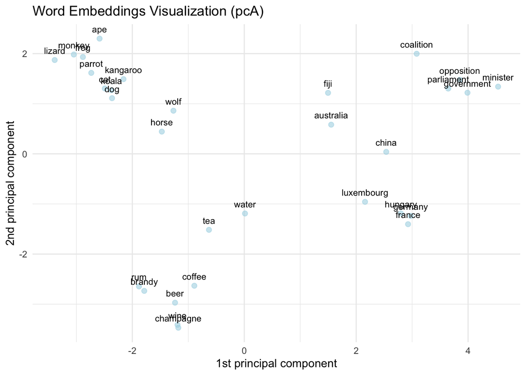

```r
# extract embeddings for existing words

# apply pcA
pca_result <- prcomp(wv[existing_words, ], center = TRUE, scale. = FALSE)
pcs <- pca_result$x[, 1:2]

# create data frame for plotting
plot_data <- data.frame(
  word = existing_words,
  pc1 = pcs[, 1],
  pc2 = pcs[, 2]
)

# create plot with ggplot2
ggplot(plot_data, aes(x = pc1, y = pc2, label = word)) +
  geom_point(color = "lightblue", alpha = 0.6, size = 2) +
  geom_text(vjust = -1, hjust = 0.5, size = 3) +
  labs(
    title = "Word Embeddings Visualization (pcA)",
    x = "1st principal component",
    y = "2nd principal component"
  ) +
  theme_minimal()
```

**Data dependence**

Where a word ends up in the 2D space depends on the set of word vectors used to fit the PCA.

So if you change the selection of words, you get a different 2D clustering of words.

### 2.2 Computing similarities

An central quantity of interest in the study of lexical semantics (i.e., the “meaning” of words) is **word similarity** — how similar the “meanings” of two words are.

In CSS studies using word embeddings, computating similarities is often an essential computation step.

#### Intuition

In the embedding space, we can **measure two word vectors’ similarity** of by their *angle*: the extent to which they *point in similar directions* relative to the coordiante origin $(0, 0, \ldots, 0)$.

Say you stand at the origin of a $d$-dimensional coordinate system. Then asking whether two vectors $\mathbf{u}$ and $\mathbf{v}$ are similar is the same as asking:

> “Would I end up in a similar location if I follow the direction of vector $\mathbf{u}$ rather than $\mathbf{v}$?”

The answer to this question aligns with the magnitude of the angle:

- If the two vectors are very similar, you’d end up in a similar location (e.g., $\mathbf{u} = [1, 1]$ and $\mathbf{u} = [.8, .9]$)
- If they are pointing in completely opposite directions, you’ll end up on the other “side” of the vector space if you follow $\mathbf{u}$ rather than $\mathbf{v}$ (e.g., (e.g., $\mathbf{u} = [1, 1]$ and $\mathbf{u} = [-1, -1]$)

#### Illustration

The below plot visually illustrates this, given the following vectors (i.e., 2D points):

```r
# define example vectors
vecs <- matrix(c(
  1.0,  1.0,  # vector a
  0.8,  0.9,  # vector b
  0.5,  0.2,  # vector c
 -1.0,  1.0,  # vector d
 -1.0, -1.0   # vector e
), ncol = 2, byrow = TRUE)

rownames(vecs) <- vec_names <- c("a", "b", "c", "d", "e")
colnames(vecs) <- c("x", "y")
print(vecs)
```

```
     x    y
a  1.0  1.0
b  0.8  0.9
c  0.5  0.2
d -1.0  1.0
e -1.0 -1.0
```

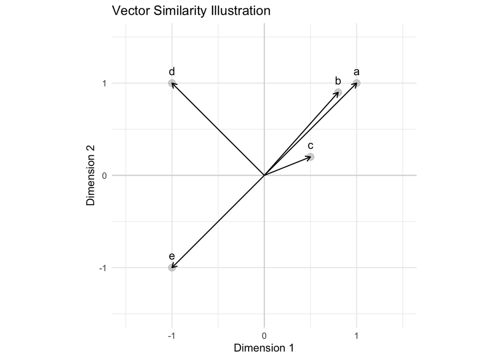

```r
# create visualization with ggplot2
vec_df <- as.data.frame(vecs)
vec_df$name <- row.names(vec_df)

# create arrows from origin to each point
arrow_df <- data.frame(
  x = rep(0, nrow(vecs)),
  y = rep(0, nrow(vecs)),
  xend = vecs[, 1],
  yend = vecs[, 2]
)

ggplot(data = vec_df, aes(x = x, y = y, label = name)) +
  geom_hline(yintercept = 0, color = "grey", alpha = 0.5) +
  geom_vline(xintercept = 0, color = "grey", alpha = 0.5) +
  geom_point(color = "darkgrey", size = 3, alpha = 0.5) +
  geom_text(vjust = -1, hjust = 0.5, size = 4) +
  geom_segment(
    data = arrow_df,
    mapping = aes(xend = xend, yend = yend, label = NULL),
    arrow = arrow(length = unit(0.2, "cm")),
    color = "black", linewidth = 0.5
  ) +
  labs(
    title = "Vector Similarity Illustration",
    x = "Dimension 1",
    y = "Dimension 2"
  ) +
  lims(
    x = c(-1.5, 1.5),
    y = c(-1.5, 1.5)
  ) +
  coord_fixed() +
  theme_minimal()
```

So in this example,

- $\mathbf{a}$ and $\mathbf{b}$ are very similar (because they point in a similar direction)
- $\mathbf{a}$ and $\mathbf{c}$, and $\mathbf{b}$ and $\mathbf{c}$ are also still somewhat similar
- $\mathbf{a}$ and $\mathbf{d}$ are orthogonal (“unrelated”), and
- $\mathbf{a}$ and $\mathbf{e}$ are maximally dissimilar (because they point in opposite directions)

#### Math

The extent to which they point in similar directions relative to the coordinate origin $(0, 0, \ldots, 0)$ can be measured by the **cosine similarity**:

$$\text{Cosine Similarity} = \frac{{\mathbf{u} \cdot \mathbf{v}}}{{\| \mathbf{u} \| \times \| \mathbf{v} \|}}$$

$\mathbf{u}$ and $\mathbf{v}$ are the vectors whose similarity is being measured.

The $\boldsymbol{\cdot}$ operator denotes the **dot product** of two vectors. It measures the *similarity in the direction of two vectors.* (Think of vectors as directions from the origin $(0, 0, \ldots, 0)$).

- The dot product is computed as the sum of the element-wise products of vectors’ entries:
  $$\mathbf{u} \cdot \mathbf{v} = \sum\limits_{i=1}^{d} u_i \times v_i$$
- $u_i \times v_i$ is high if the two entries are similar (point in the same directio nrelative to the coordinate origin $0$)
- Thus, $\mathbf{u} \cdot \mathbf{v}$ is the higher, the more of their $(u_i, v_i)$ elements are similar.

$\| \mathbf{u} \|$ and $\| \mathbf{v} \|$ represent the **Euclidean norms** (magnitudes) of vectors $\mathbf{u}$ and $\mathbf{v}$. The magnitude (or length) of a vector measures its *distance from the origin in the $d$-dimensional space.* It is computed as

$$\| \mathbf{x} \| = \sqrt{ \sum\limits_{i=1}^{d} x_i^2}$$

Having the $\| \mathbf{u} \| \times \| \mathbf{v} \|$ in the denominator if the cosine similarity function makes the metric scale invariant (i.e., insensitive to the lengths/magnitudes of $\mathbf{u}$ and $\mathbf{v}$).

#### Code (from scratch)

```r
# define a function to compute cosine similarity between two word vectors
cosine_similarity <- function(u, v) {
  # Compute the dot product between u and v
  dot_product <- sum(u * v)

  # Compute the Euclidean norms (magnitudes)
  norm_u <- sqrt(sum(u^2))
  norm_v <- sqrt(sum(v^2))

  # Compute cosine similarity
  cosine_sim <- dot_product / (norm_u * norm_v)

  return(cosine_sim)
}
```

Let’s compute similarities for our example 2D-vectors in `vecs`:

```r
# compute similarities of vectors b-e to vector a
for (i in 2:nrow(vecs)) {
  s <- cosine_similarity(vecs[1, ], vecs[i, ])
  cat(sprintf("a = [%+.1f, %+.1f], %s = [%+.1f, %+.1f], cos(a, %s) = %+.3f\n",
              vecs[1, 1], vecs[1, 2], rownames(vecs)[i],
              vecs[i, 1], vecs[i, 2], rownames(vecs)[i], s))
}
```

```
a = [+1.0, +1.0], b = [+0.8, +0.9], cos(a, b) = +0.998
a = [+1.0, +1.0], c = [+0.5, +0.2], cos(a, c) = +0.919
a = [+1.0, +1.0], d = [-1.0, +1.0], cos(a, d) = +0.000
a = [+1.0, +1.0], e = [-1.0, -1.0], cos(a, e) = -1.000
```

Let’s apply the same function to compute the similarity of two words in our GloVe embeddings:

```r
# compute cosine similarity for two word vectors
sim <- cosine_similarity(wv["good", ], wv["bad", ])
cat("Cosine similarity between 'good' and 'bad':", sim, "\n")
```

```
Cosine similarity between 'good' and 'bad': 0.8137627
```

#### Code (wrapper function)

Let’s define a wrapper function for computing the similarity of a pair of words given their word vectors.

```r
# function to compute cosine similarity between two words
word_similarity <- function(embeddings, word1, word2) {
  if (!word1 %in% rownames(embeddings) || !word2 %in% rownames(embeddings)) {
    warning("One or both words not found in vocab")
    return(NA)
  }

  v1 <- embeddings[word1, ]
  v2 <- embeddings[word2, ]

  # Using built-in functions
  cosine_sim <- sum(v1 * v2) / (sqrt(sum(v1^2)) * sqrt(sum(v2^2)))
  return(cosine_sim)
}

# example usage
word_similarity(wv, "good", "bad")
```

```
[1] 0.8137627
```

#### Exercise 1: Word association bias

Let’s implement a classic approach to evaluate how word embeddings capture cultural biases in their training corpora. Here, we’ll focus on *gender bias* — the differential association of traits and attributes with women and men (my loose definition).

Compile a list `comparison_words` with occupations, character traits, and other words that might exhibit gender bias. Then compute how similar each word is with terms like ‘man’ and ‘woman’, that indicate the male and female genders.

Which words exhibit gender bias? And in which direction? Do you spot a pattern?

```r
comparison_words <- c(
  "programmer",
  "scientist",
  "smart",
  "emotional",
  "caring"
  # TODO: add more interesting words here
)
```

```r
# compute similarities to male and female terms
male_terms <- c("man")
female_terms <- c("woman")

# TODO: implement logic
results <- list()
for (word in comparison_words) {
  if (word %in% rownames(wv)) {
    male_sim <- word_similarity(wv, word, male_terms[1])
    female_sim <- word_similarity(wv, word, female_terms[1])
    res <- data.frame(word, male_sim, female_sim, bias = male_sim - female_sim)
    results[[length(results)+1L]] <- res
  }
}
results <- do.call(rbind, results)
```

```r
# TODO: summarize the results in a table or figure
# hint: if you have more than one term per gender, you might want to compute the average of comparison term--gender word similarities
```

### 2.3. Finding most similar terms (nearest neighbors)

Since word vectors capture similarities in words co-occurence patterns, their locations in the embedding space can be use to find lists of semantically and functionally similar words.

#### Intuition

In the embedding space, searching for similar words for a focus word *w* can be implemented as [*nearest neighbors* search](https://en.wikipedia.org/wiki/Nearest_neighbour_algorithm) because words pairs’ distances measure their similarity.

#### Illustration

Let’s use the same 2-dimensional vectors `vecs` as in the example above.

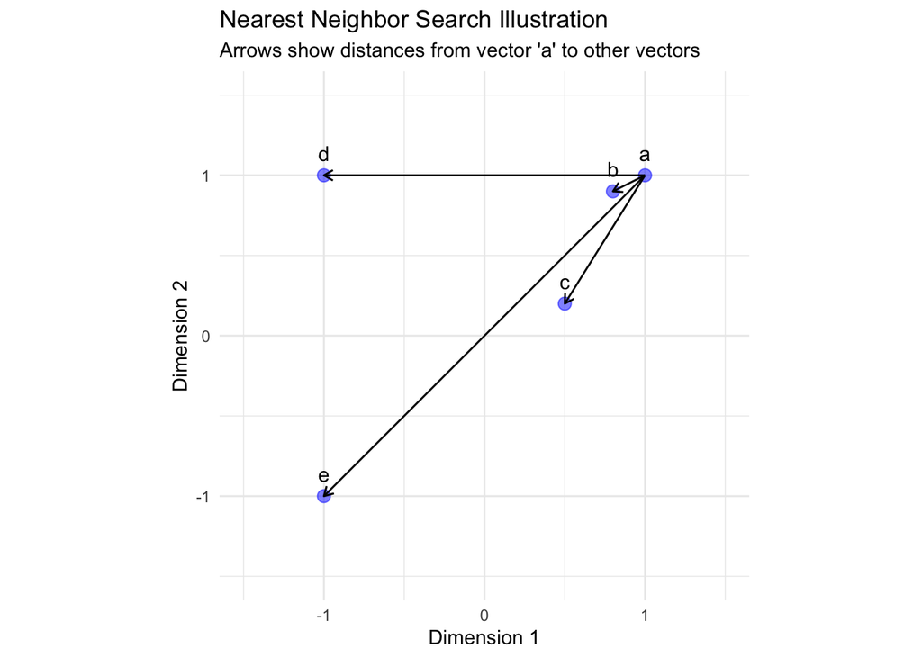

```r
# create arrows from vector a to all other vectors
arrow_df <- data.frame(
  x = rep(vecs[1, 1], 4),      # from vector a
  y = rep(vecs[1, 2], 4),      # from vector a
  xend = vecs[2:5, 1],         # to vectors b-e
  yend = vecs[2:5, 2]          # to vectors b-e
)

ggplot(data = vec_df, aes(x = x, y = y, label = name)) +
  geom_point(size = 3, color = "blue", alpha = 0.5) +
  geom_text(vjust = -1, hjust = 0.5, size = 4) +
  geom_segment(
    data = arrow_df,
    mapping = aes(xend = xend, yend = yend, label = NULL),
    arrow = arrow(length = unit(0.2, "cm")),
    color = "black", linewidth = 0.5
  ) +
  labs(
    title = "Nearest Neighbor Search Illustration",
    subtitle = "Arrows show distances from vector 'a' to other vectors",
    x = "Dimension 1",
    y = "Dimension 2"
  ) +
  lims(
    x = c(-1.5, 1.5),
    y = c(-1.5, 1.5)
  ) +
  coord_fixed() +
  theme_minimal()
```

#### Code

So we can find out what’s the most similar vector to **a** by

1. computing all vectors (**b**-**e**) similarity with **a**, and
2. selecting the one with the highest similarity among them

```r
# compute similarities of all vectors to vector a
sims <- sapply(2:nrow(vecs), function(i) {
  cosine_similarity(vecs[1, ], vecs[i, ])
})
names(sims) <- vec_names[2:5]

print(sims)
```

```
         b          c          d          e
 0.9982744  0.9191450  0.0000000 -1.0000000
```

```r
# get name of most similar vector
most_similar <- names(sims)[which.max(sims)]
cat("Most similar to 'a':", most_similar, "\n")
```

```
Most similar to 'a': b
```

Now let’s implement this for our word embeddings:

```r
# function to find most similar words to a target word
most_similar_words <- function(target_word, embeddings, topn = 10) {
  if (!target_word %in% rownames(embeddings)) {
    stop("Target word not found in vocab")
  }

  target_vec <- embeddings[target_word, ]
  similarities <- apply(embeddings, 1, function(word_vec) {
    cosine_similarity(target_vec, word_vec)
  })

  # Remove the target word itself
  similarities <- similarities[names(similarities) != target_word]

  # Sort by similarity and return top n
  top_indices <- order(similarities, decreasing = TRUE)[1:topn]
  result <- data.frame(
    word = names(similarities)[top_indices],
    similarity = similarities[top_indices],
    stringsAsFactors = FALSE
  )

  return(result)
}

# example usage
similar_to_mother <- most_similar_words("mother", wv, topn = 10)
similar_to_mother
```

```
                   word similarity
wife               wife  0.9546155
daughter       daughter  0.9504356
grandmother grandmother  0.9422797
husband         husband  0.9261272
sister           sister  0.9147193
woman             woman  0.9072891
aunt               aunt  0.9027934
her                 her  0.9027531
daughters     daughters  0.8949396
father           father  0.8930612
```

```r
# show just the words (like the Python version)
similar_to_love <- most_similar_words("love", wv, topn = 10)
cat("Words most similar to 'love':", paste(similar_to_love$word, collapse = ", "), "\n")
```

```
Words most similar to 'love': dreams, dream, loves, mind, life, wonder, my, me, goes, happy
```

**Note**

“Similar” in the context of word embeddings does *not* necessarily mean [*synonym*](https://en.wikipedia.org/wiki/Synonym) (i.e.. equal in meaning). Instead, word embeddings capture a wide range of lexical semantic relations

- synonyms
- antonyms
- hypo- and hypernym relations (subtype relations): https://en.wikipedia.org/wiki/Hyponymy_and_hypernymy
- mero- and hoponym relations (part-of relations): https://en.wikipedia.org/wiki/Meronymy_and_holonymy

#### Exercise 2: Finding nearest neighbors

Let’s use nearest neighbors search to find conceptually equivalent terms for a “seed” word.

**Note**

This is a typical task in expanding keyword lists for dictionaries. For example, in Osnabgügge *et al.* ([2021](https://doi.org/10.1017/S0003055421000356)) or Hargrave and Blumenau ([2022](https://doi.org/10.1017/10.1017/S0007123421000648).

You can choose which seed word you want to start with (see example below for a suggestion). But while going through nearest neighbors, keep track of how many of the candidate terms in the top-20 or top-50 terms (or so) you would include in your dictionary, and how many you would discard!

*Example*: Say you want to compile a dictionary that contains typical words used to express *positive emotions*. In this case, you could start with the seed word ‘happy.’

```r
# find words similar to "happy"
happy_similar <- most_similar_words("happy", wv, topn = 40)
print(happy_similar$word)
```

```
 [1] "'m"         "everyone"   "really"     "always"     "everybody"
 [6] "definitely" "me"         "'d"         "something"  "maybe"
[11] "good"       "feel"       "glad"       "thing"      "'re"
[16] "'ll"        "wonder"     "i"          "think"      "imagine"
[21] "know"       "wish"       "remember"   "going"      "sure"
[26] "nothing"    "we"         "you"        "myself"     "come"
[31] "things"     "n't"        "go"         "lucky"      "feels"
[36] "knowing"    "'ve"        "seeing"     "else"       "anyway"
```

Terms like “good”, “glad”, and “lucky” are conceptually related. But many other terms’ similarity is likely mostly driven by syntactic and grammatical aspects of word co-occurences.

```r
# TODO: pick another emotion word, list the 20 most similar words,
# and decide which ones you would approve as well
emo_word <- "sad"  # TODO: change this to your chosen emotion word

if (emo_word %in% rownames(wv)) {
  similar_words <- most_similar_words(emo_word, wv, topn = 20)
  print(similar_words$word)
} else {
  cat(paste("'", emo_word, "' not found in vocab\n", sep = ""))
}
```

```
 [1] "awful"      "sorry"      "feeling"    "horrible"   "terrible"
 [6] "feels"      "sadly"      "tragic"     "thing"      "scary"
[11] "terribly"   "feel"       "irony"      "moment"     "happened"
[16] "pretty"     "shocking"   "happy"      "weird"      "absolutely"
```

### 2.4. Computing centroids

Just as we use keywords in dictionaries to indicate concepts (e.g., positive affect), we can use bags of word vectors to “locate” concepts in the embedding space.

Because each indicator word’s embedding might capture a concept only partially, researchers often **average multiple words’ embeddings into *centroids***.

This is as simple as computing the mean of vectors value for each embedding dimension. With our R matrix, this is straightforward using base R functions:

```r
# take example of words used to indicate concept 'positive sentiment'
positive_sentiment_words <- c(
  "glad",
  "pleased",
  "ecstatic",
  "overjoyed",
  "thrilled",
  "satisfied",
  "proud",
  "delighted",
  "excited",
  "elated",
  "thankful",
  "grateful",
  "confident"
)

# get word vectors for words that exist in our vocab
existing_words <- positive_sentiment_words[positive_sentiment_words %in% rownames(wv)]
cat("Found", length(existing_words), "out of", length(positive_sentiment_words), "words in vocab\n")
```

```
Found 13 out of 13 words in vocab
```

```r
cat("Existing words:", paste(existing_words, collapse = ", "), "\n")
```

```
Existing words: glad, pleased, ecstatic, overjoyed, thrilled, satisfied, proud, delighted, excited, elated, thankful, grateful, confident
```

```r
# check we have some words
length(existing_words) > 0
```

```
[1] TRUE
```

```r
# extract vectors for existing words
sentiment_vectors <- wv[existing_words, ]
cat("Shape of sentiment vectors matrix:", dim(sentiment_vectors), "\n")
```

```
Shape of sentiment vectors matrix: 13 50
```

```r
# compute centroid by averaging across words (rows)
centroid <- colMeans(sentiment_vectors)
cat("Centroid vector length:", length(centroid), "\n")
```

```
Centroid vector length: 50
```

```r
cat("First 10 dimensions:", centroid[1:10], "\n")
```

```
First 10 dimensions: -0.3852684 0.2272928 0.02946515 0.5685437 0.9732628 -0.5365584 -0.3992534 0.06209146 0.2048452 -0.2109065
```

```r
# NOTE: also useful to compute "sentence embedding"
sentence <- "Just write a random sentence."
words <- unlist(strsplit(sentence, " "))
words <- tolower(gsub("[[:punct:]]", "", words))  # remove punctuation and convert to lowercase

# get sentence embedding by averaging word vectors
existing_sentence_words <- words[words %in% rownames(wv)]
sentence_embedding <- colMeans(wv[existing_sentence_words, ])
cat("Sentence embedding length:", length(sentence_embedding), "\n")
```

```
Sentence embedding length: 50
```

```r
cat("Words found in vocab:", paste(existing_sentence_words, collapse = ", "), "\n")
```

```
Words found in vocab: just, write, a, random, sentence
```

```r
# check similarity of sentence embedding to individual words
if (length(existing_sentence_words) > 0) {
  for (word in words) {
    if (word %in% rownames(wv)) {
      sim <- cosine_similarity(sentence_embedding, wv[word, ])
      cat(word, ":", round(sim, 4), "\n")
    } else {
      cat(word, ": -/-\n")
    }
  }
}
```

```
just : 0.8851
write : 0.7997
a : 0.8954
random : 0.7223
sentence : 0.7525
```

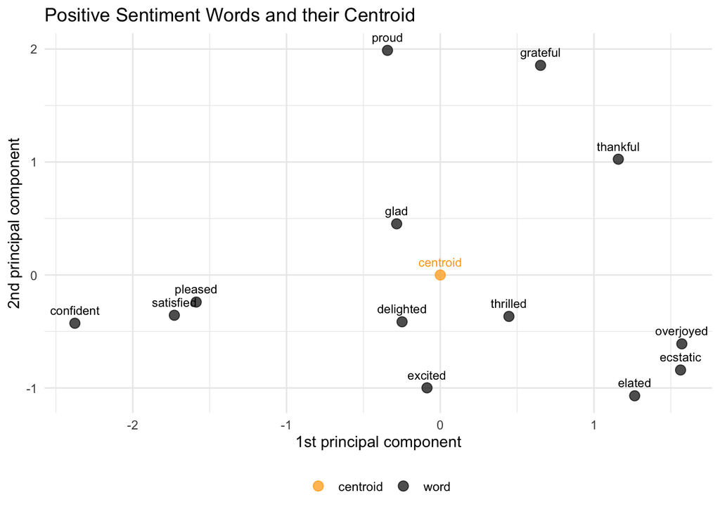

```r
# combine original vectors with centroid for visualization

# add centroid to the sentiment vectors
combined_vecs <- rbind(sentiment_vectors, centroid)
rownames(combined_vecs)[nrow(combined_vecs)] <- "centroid"

# apply pcA
pca_result <- prcomp(combined_vecs, center = TRUE, scale. = FALSE)
pcas <- pca_result$x[, 1:2]

# create data frame for plotting
plot_data <- data.frame(
  pc1 = pcas[, 1],
  pc2 = pcas[, 2],
  word = rownames(combined_vecs),
  type = c(rep("word", nrow(sentiment_vectors)), "centroid")
)

# create plot
ggplot(plot_data, aes(x = pc1, y = pc2, color = type, label = word)) +
  geom_point(size = 3, alpha = 0.7) +
  geom_text(vjust = -1, hjust = 0.5, size = 3, show.legend = FALSE) +
  scale_color_manual(values = c("word" = "black", "centroid" = "orange")) +
  labs(
    title = "Positive Sentiment Words and their Centroid",
    x = "1st principal component",
    y = "2nd principal component",
    color = NULL
  ) +
  theme_minimal() +
  theme(legend.position = "bottom")
```

#### Excurse: Using centroids to find mismatching terms (the “odd one out”)

We can use centroids to find the most mismatching term in a list of terms.

For this, we

1. compute the centroid of all but the focus term’s embeddings,
2. compute the similarity of the focus term’s embedding and the centroid,
3. repeat this leave-one-out procedure for all terms, and
4. label the one with the lowest to-centroid similarity as “mismatching”

```r
terms <- c("cat", "dog", "cow", "flower")

# check which terms exist in vocab
existing_terms <- terms[terms %in% rownames(wv)]
cat("Terms found in vocab:", paste(existing_terms, collapse = ", "), "\n")
```

```
Terms found in vocab: cat, dog, cow, flower
```

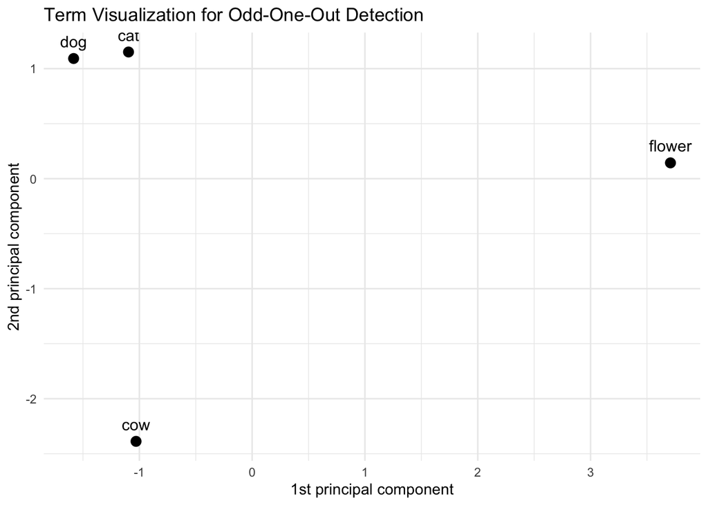

```r
# apply pcA to visualize the terms
term_vectors <- wv[existing_terms, ]
pca_result <- prcomp(term_vectors, center = TRUE, scale. = FALSE)
pcs <- pca_result$x[, 1:2]

plot_data <- data.frame(
  pc1 = pcs[, 1],
  pc2 = pcs[, 2],
  term = existing_terms
)

ggplot(plot_data, aes(x = pc1, y = pc2, label = term)) +
  geom_point(size = 3) +
  geom_text(vjust = -1, hjust = 0.5, size = 4) +
  labs(
    title = "Term Visualization for Odd-One-Out Detection",
    x = "1st principal component",
    y = "2nd principal component"
  ) +
  theme_minimal()
```

```r
# function to find the odd one out
find_odd_one_out <- function(terms, embeddings) {
  existing_terms <- terms[terms %in% rownames(embeddings)]

  if (length(existing_terms) < 3) {
    stop("Need at least 3 terms that exist in vocab")
  }

  similarities <- numeric(length(existing_terms))
  names(similarities) <- existing_terms

  for (i in seq_along(existing_terms)) {
    term <- existing_terms[i]
    other_terms <- existing_terms[-i]

    # Compute centroid of all other terms
    centroid <- colMeans(embeddings[other_terms, ])

    # Compute similarity between term and centroid
    similarities[i] <- cosine_similarity(embeddings[term, ], centroid)
  }

  cat("Similarities to leave-one-out centroids:\n")
  for (i in seq_along(similarities)) {
    cat(sprintf("%s: %.3f\n", names(similarities)[i], similarities[i]))
  }

  # Find the term with lowest similarity
  odd_one_out <- names(similarities)[which.min(similarities)]
  return(list(odd_one_out = odd_one_out, similarities = similarities))
}

# apply to our example terms
result <- find_odd_one_out(existing_terms, wv)
```

```
Similarities to leave-one-out centroids:
cat: 0.867
dog: 0.848
cow: 0.764
flower: 0.546
```

```r
cat("\nThe mismatching term is:", result$odd_one_out, "\n")
```

```
The mismatching term is: flower
```

### 2.5. Solving analogies

“Well-behaved” word embeddings exhibit the ability to automate much more complex tasks than finding synonyms, antonyms, and mismatching terms.

One of word embedding models’ powers that has attracted a lot of attention when Tomas Mikolov *et al.* and Pennigton *et al.* released word2vec and GloVe, respectively, was their ability to solve analogy tasks.

**Analogy tasks** are simple national language inference problems that prompt a model to infer the Y2 in the following relational statement:

> `X1 is to Y1 as X2 is to Y2.`

For example, a frequently cited analogy problem is,

> `Man is to woman as king is to _____?`

#### Intuition

One can solve analogy problems with word embeddings by performing applying the following geometric operations:

1. View the statement `X1 is to Y1` as an instruction to move from the location of X1 in the direction of Y1.
2. To get to Y2, take the same direction but start from X2.

The following figure from [Jurafsky & Martin (2023)](https://web.stanford.edu/~jurafsky/slp3/6.pdf) illustrates this idea for the analogy “apple is to tree as grape is to vine:”

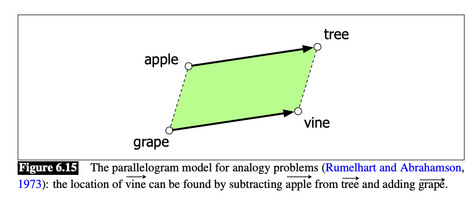

#### Math

Let’s take the analogy problem

> ‘man’ is to ‘woman’ as ‘king’ is to ‘_____’?

This can be “solved” by computing with word vectors by performing the following arithmetic operation with the word vectors of, king, man, and woman:

$$\begin{align}
\mathbf{v}_\text{man} - \mathbf{v}_\text{woman} &\approx \mathbf{v}_\text{king} - \mathbf{v}_\text{?}\\
\mathbf{v}_\text{king} - \mathbf{v}_\text{man} + \mathbf{v}_\text{woman} &\approx \mathbf{v}_\text{?}
\end{align}$$

The **closest word vector to** $\mathbf{v}_\text{?}$ is the best model’s best guess for completing the analogy problem.

This works because

- the operation $(\mathbf{v}_\text{woman} - \mathbf{v}_\text{man})$ spans a “gender dimension”: $\mathbf{v}_\text{gender}$
- adding $\mathbf{v}_\text{gender}$ to $\mathbf{v}_\text{king}$ means to depart from ‘king’ and move along the gender dimension into the direction of “femininity”

(see Kozlowski *et al.*, [2019](https://doi.org/10.1177/0003122419877135), p. 912, for further examples)

#### Code (from scratch)

```r
# check if the analogy words exist in vocab
analogy_words <- c("king", "man", "woman")
existing_analogy <- analogy_words[analogy_words %in% rownames(wv)]
cat("Analogy words found:", paste(existing_analogy, collapse = ", "), "\n")
```

```
Analogy words found: king, man, woman
```

```r
if (length(existing_analogy) == 3) {
  v_king <- wv["king", ]
  v_man <- wv["man", ]
  v_woman <- wv["woman", ]

  # Compute the analogy vector: king - man + woman
  v_q <- v_king - v_man + v_woman
  cat("Query vector length:", length(v_q), "\n")

  # Find most similar words to the query vector
  similarities <- apply(wv, 1, function(word_vec) {
    cosine_similarity(v_q, word_vec)
  })

  # Remove the input words from results
  similarities <- similarities[!names(similarities) %in% analogy_words]

  # Get top 5 results
  top_results <- head(sort(similarities, decreasing = TRUE), 5)
  cat("Top 5 analogy completions:\n")
  for (i in seq_along(top_results)) {
    cat(sprintf("%d. %s (%.3f)\n", i, names(top_results)[i], top_results[i]))
  }
}
```

```
Query vector length: 50
Top 5 analogy completions:
1. queen (0.872)
2. daughter (0.806)
3. throne (0.785)
4. eldest (0.781)
5. elizabeth (0.779)
```

#### Code (wrapper function)

Let’s define a more intuitive wrapper function for analogy solving:

```r
# function to solve analogies: "x1 is to y1 as x2 is to ?"
solve_analogy <- function(x1, y1, x2, embeddings, topn = 5, verbose = TRUE) {
  # Check if all words exist
  words <- c(x1, y1, x2)
  missing <- words[!words %in% rownames(embeddings)]
  if (length(missing) > 0) {
    stop(paste("Words not found in vocab:", paste(missing, collapse = ", ")))
  }

  # Get vectors
  v_x1 <- embeddings[x1, ]
  v_y1 <- embeddings[y1, ]
  v_x2 <- embeddings[x2, ]

  # Compute analogy vector: y1 - x1 + x2
  v_q <- v_y1 - v_x1 + v_x2

  # Find similarities
  similarities <- apply(embeddings, 1, function(word_vec) {
    cosine_similarity(v_q, word_vec)
  })

  # Remove input words
  similarities <- similarities[!names(similarities) %in% words]

  # Get top results
  top_results <- head(sort(similarities, decreasing = TRUE), topn)

  if (verbose) {
    cat(sprintf("'%s' : '%s' :: '%s' : ?? ==> '%s'\n",
                x1, y1, x2, names(top_results)[1]))
  }

  result <- data.frame(
    word = names(top_results),
    similarity = as.numeric(top_results),
    stringsAsFactors = FALSE
  )

  return(result)
}

# example usage
solve_analogy("man", "king", "woman", wv)
```

```
'man' : 'king' :: 'woman' : ?? ==> 'queen'
```

```
       word similarity
1     queen  0.8715485
2  daughter  0.8064809
3    throne  0.7852034
4    eldest  0.7805679
5 elizabeth  0.7787424
```

**Note**

Analogies are another way to assess gender bias

```r
solve_analogy("man", "power", "woman", wv)
```

```
'man' : 'power' :: 'woman' : ?? ==> 'control'
```

```
         word similarity
1     control  0.7911783
2     support  0.7662312
3  separation  0.7599418
4          to  0.7551455
5 controlling  0.7538998
```

```r
solve_analogy("man", "smart", "woman", wv)
```

```
'man' : 'smart' :: 'woman' : ?? ==> 'tailor'
```

```
         word similarity
1      tailor  0.7251652
2         mom  0.7138133
3 intelligent  0.7083201
4        kids  0.6882891
5   conscious  0.6817237
```

### Exercise 3: Analogies

Can you come up with analogy problems involving terms from your discipline or research area? Can the word embedding model solve these specialized problems?

*Example:* In politics “Republican is to conservative what Democrat is to ___?”

```r
# check if political terms exist in vocab
solve_analogy("republican", "conservative", "democrat", wv, topn = 5)
```

```
'republican' : 'conservative' :: 'democrat' : ?? ==> 'liberal'
```

```
           word similarity
1       liberal  0.9187328
2      centrist  0.8264125
3 conservatives  0.8010923
4      liberals  0.7851788
5    politician  0.7674775
```

```r
# TODO: Try your own analogy with terms that exist in the vocab
# example format:
# your_result <- solve_analogy("word1", "word2", "word3", wv)
```